# Survival_Analysis_week2

202430527 leetaenyoung

2025-09-28

## 1 Week 3 assignment

### 1.1 Question 1

#### 1.1.1 Data-Library import

```r
library(survival)
vets <- read.table("vets.txt", header = TRUE)
```

#### 1.1.2 pre-processing

```r
# integrate 4 level CT into one factor column(cell)
vets$cell <- ifelse(vets$CT1 == 1, "large",
              ifelse(vets$CT2 == 1, "adeno",
              ifelse(vets$CT3 == 1, "small",
                     "squamous")))
vets$cell <- factor(vets$cell,
                     levels = c("large", "adeno", "small", "squamous"))

# 치료: 1=standard, 2=test; test=1, standard=0로 인코딩
vets$TrtTest <- as.integer(vets$Trt == 2)
```

#### 1.1.3 (a)

*Cox-PH model* :
$$h(t\mid \mathbf{x}) \;=\; h_0(t)\,\exp\!\big(
\beta_{\text{Trt}}\cdot \text{Treatment}
+ \beta_{\text{A}}\cdot I\{\text{Adeno}\}
+ \beta_{\text{S}}\cdot I\{\text{Small}\}
+ \beta_{\text{Q}}\cdot I\{\text{Squamous}\}
+ \beta_{\text{PS}}\cdot \text{PerfStatus}
+ \beta_{\text{DD}}\cdot \text{DiseaseDur}
+ \beta_{\text{Age}}\cdot \text{Age}
+ \beta_{\text{PT}}\cdot \text{PriorTherapy}
\big),$$

```r
# 1) Cox PH fit
fit <- coxph(
  Surv(time, status) ~ TrtTest + cell + PS + DD + age + PT,
  data = vets
)
summary(fit)
```

```
## Call:
## coxph(formula = Surv(time, status) ~ TrtTest + cell + PS + DD +
##     age + PT, data = vets)
##
##   n= 137, number of events= 128
##
##                    coef  exp(coef)   se(coef)      z Pr(>|z|)
## TrtTest       2.946e-01  1.343e+00  2.075e-01  1.419  0.15577
## celladeno     7.948e-01  2.214e+00  3.029e-01  2.624  0.00869 **
## cellsmall     4.603e-01  1.584e+00  2.662e-01  1.729  0.08383 .
## cellsquamous -4.013e-01  6.695e-01  2.827e-01 -1.420  0.15574
## PS           -3.282e-02  9.677e-01  5.508e-03 -5.958 2.55e-09 ***
## DD            8.132e-05  1.000e+00  9.136e-03  0.009  0.99290
## age          -8.706e-03  9.913e-01  9.300e-03 -0.936  0.34920
## PT            7.159e-03  1.007e+00  2.323e-02  0.308  0.75794
## ---
## Signif. codes:  0 '***' 0.001 '**' 0.01 '*' 0.05 '.' 0.1 ' ' 1
##
##              exp(coef) exp(-coef) lower .95 upper .95
## TrtTest         1.3426     0.7448    0.8939    2.0166
## celladeno       2.2139     0.4517    1.2228    4.0084
## cellsmall       1.5845     0.6311    0.9403    2.6699
## cellsquamous    0.6695     1.4938    0.3847    1.1651
## PS              0.9677     1.0334    0.9573    0.9782
## DD              1.0001     0.9999    0.9823    1.0182
## age             0.9913     1.0087    0.9734    1.0096
## PT              1.0072     0.9929    0.9624    1.0541
##
## Concordance= 0.736  (se = 0.021 )
## Likelihood ratio test= 62.1  on 8 df,   p=2e-10
## Wald test            = 62.37  on 8 df,   p=2e-10
## Score (logrank) test = 66.74  on 8 df,   p=2e-11
```

```r
#문제 스타일 표 만들기
co <- coef(fit)
se <- sqrt(diag(vcov(fit)))
z  <- co / se
p  <- 2 * pnorm(-abs(z))
hr <- exp(co)
ci <- exp(cbind(lwr = co - 1.96 * se, upr = co + 1.96 * se))

out <- data.frame(
  term = names(co),
  coef = round(co, 3),
  se   = round(se, 3),
  z    = round(z, 3),
  p    = signif(p, 3),
  HR   = round(hr, 3),
  CI95 = sprintf("(%.3f, %.3f)", ci[,1], ci[,2]),
  row.names = NULL
)
out
```

| term | coef | se | z | p | HR | CI95 |
| --- | --- | --- | --- | --- | --- | --- |
| TrtTest | 0.295 | 0.208 | 1.419 | 1.56e-01 | 1.343 | (0.894, 2.017) |
| celladeno | 0.795 | 0.303 | 2.624 | 8.69e-03 | 2.214 | (1.223, 4.008) |
| cellsmall | 0.460 | 0.266 | 1.729 | 8.38e-02 | 1.584 | (0.940, 2.670) |
| cellsquamous | -0.401 | 0.283 | -1.420 | 1.56e-01 | 0.669 | (0.385, 1.165) |
| PS | -0.033 | 0.006 | -5.958 | 2.55e-09 | 0.968 | (0.957, 0.978) |
| DD | 0.000 | 0.009 | 0.009 | 9.93e-01 | 1.000 | (0.982, 1.018) |
| age | -0.009 | 0.009 | -0.936 | 3.49e-01 | 0.991 | (0.973, 1.010) |
| PT | 0.007 | 0.023 | 0.308 | 7.58e-01 | 1.007 | (0.962, 1.054) |

#### 1.1.4 (b)

For Adeno versus Large cell type,
$$\mathrm{HR} = \exp(\beta_{\text{A}}).$$
From the estimates, $\hat\beta_{\text{A}}=0.795$, hence
$$\widehat{\mathrm{HR}}_{\text{Adeno vs Large}}
= \exp(0.795) \approx 2.214.$$

#### 1.1.5 (c)

Comparing Adeno and Squamous cell types,
$$\mathrm{HR} = \exp(\beta_{\text{A}} - \beta_{\text{Q}}).$$
From the estimates, $\hat\beta_{\text{A}}=0.795$ and $\hat\beta_{\text{Q}}=-0.401$,
$$\widehat{\mathrm{HR}}_{\text{Adeno vs Squamous}}
= \exp(0.795 - (-0.401)) = \exp(1.196) \approx 3.31.$$

#### 1.1.6 (d)

The treatment coefficient is $\hat\beta_{\text{Trt}}=0.295$ with $p=0.156$, giving
$$\widehat{\mathrm{HR}} = \exp(0.295) \approx 1.34,\quad
95\%~\mathrm{CI}:\;(0.89,\;2.0).$$
Because $p>0.05$ and the CI includes 1, there is no significant treatment effect at the 5% level.

#### 1.1.7 (e)

For a patient with Test treatment and Squamous cell type,
$$\eta \;=\; \hat\beta_{\text{Trt}}\cdot 1
+ \hat\beta_{\text{Q}}\cdot 1
+ \hat\beta_{\text{PS}}\cdot \text{PS}
+ \hat\beta_{\text{DD}}\cdot \text{DD}
+ \hat\beta_{\text{Age}}\cdot \text{Age}
+ \hat\beta_{\text{PT}}\cdot \text{PT}.$$
The estimated survival function is
$$\widehat{S}(t\mid \mathbf{x})
= \widehat{S}_0(t)^{\exp(\eta)},$$
where $\widehat{S}_0(t)$ is the estimated baseline survival.

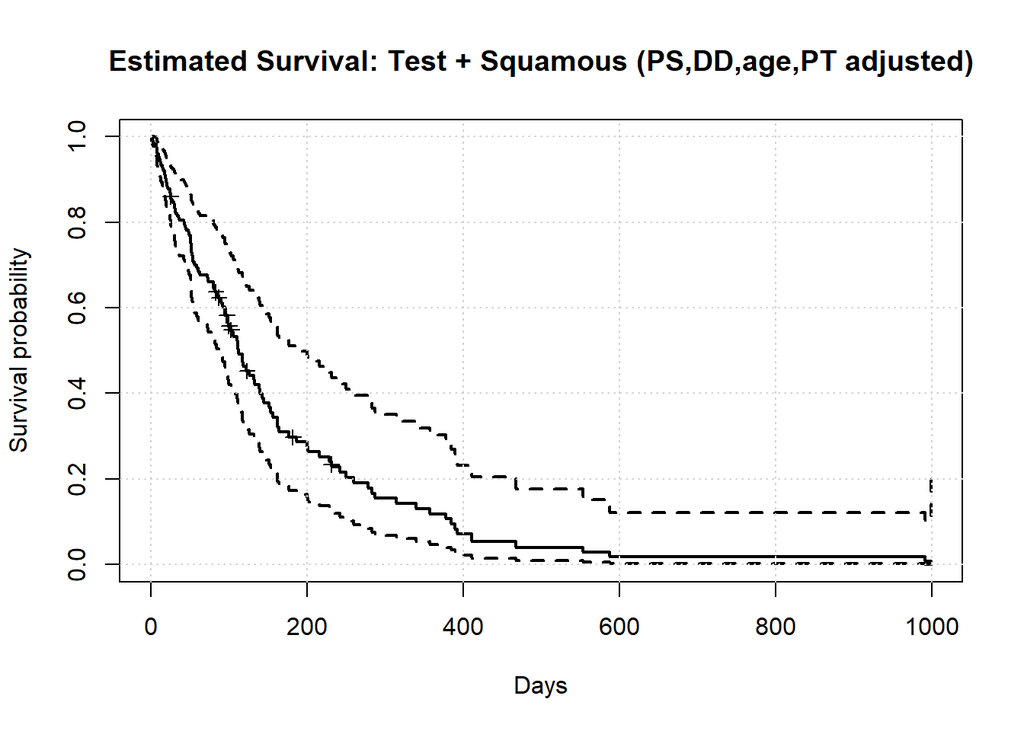

```r
PS_  <- mean(vets$PS,  na.rm = TRUE)
DD_  <- mean(vets$DD,  na.rm = TRUE)
age_ <- mean(vets$age, na.rm = TRUE)
PT_  <- mean(vets$PT,  na.rm = TRUE)

nd <- data.frame(
  TrtTest = 1L,  # Test
  cell    = factor("squamous", levels = levels(vets$cell)),
  PS  = PS_,
  DD  = DD_,
  age = age_,
  PT  = PT_
)

sf <- survfit(fit, newdata = nd)

plot(
  sf,
  xlab = "Days", ylab = "Survival probability",
  main = "Estimated Survival: Test + Squamous (PS,DD,age,PT adjusted)",
  mark.time = TRUE, lwd = 2
)
grid()
```

### 1.2 Question 2

#### 1.2.1 Data-Library import

```r
library(survival)
remission <- read.table("remission.txt", header = TRUE)
```

#### 1.2.2 pre-processing

```r
colnames(remission) <- c("time", "status", "Rx", "sex", "logWBC")
```

#### 1.2.3 Model

```r
cox1 <- coxph(Surv(time, status) ~ Rx + sex + logWBC + Rx:sex + Rx:logWBC, data = remission)
cox2 <- coxph(Surv(time, status) ~ Rx + sex + logWBC + Rx:sex, data = remission)
cox3 <- coxph(Surv(time, status) ~ Rx + sex + Rx:sex, data = remission)
cox4 <- coxph(Surv(time, status) ~ Rx + sex + logWBC, data = remission)
```

##### 1.2.3.1 Model summary

```r
models <- list(Model1 = cox1, Model2 = cox2, Model3 = cox3, Model4 = cox4)

out2 <- lapply(models, function(m) {
  s <- summary(m)
  data.frame(
    Variable = rownames(s$coefficients),
    Coef     = s$coefficients[, "coef"],
    StdErr   = s$coefficients[, "se(coef)"],
    p.value  = s$coefficients[, "Pr(>|z|)"],
    HR       = exp(s$coefficients[, "coef"]),
    CI.lower = exp(s$conf.int[, "lower .95"]),
    CI.upper = exp(s$conf.int[, "upper .95"])
  )
})
out2
```

```
## $Model1
##            Variable        Coef    StdErr      p.value        HR  CI.lower
## Rx               Rx  0.76666859 1.8408055 6.770549e-01 2.1525832  1.060089
## sex             sex -1.04803994 0.7609897 1.684484e-01 0.3506243  1.082098
## logWBC       logWBC  1.75100870 0.4441991 8.082328e-05 5.7604103 11.154588
## Rx:sex       Rx:sex  2.06385089 0.9161426 2.427418e-02 7.8762420  3.697536
## Rx:logWBC Rx:logWBC -0.08956086 0.5369289 8.675258e-01 0.9143326  1.376033
##               CI.upper
## Rx        3.060784e+34
## sex       4.749827e+00
## logWBC    9.441438e+05
## Rx:sex    4.006423e+20
## Rx:logWBC 1.372228e+01
##
## $Model2
##        Variable      Coef    StdErr      p.value        HR  CI.lower
## Rx           Rx  0.475225 0.5607413 3.967197e-01 1.6083760  1.708986
## sex         sex -1.083797 0.7310349 1.381937e-01 0.3383087  1.084082
## logWBC   logWBC  1.702845 0.3380458 4.720975e-07 5.4895414 16.945957
## Rx:sex   Rx:sex  2.103216 0.8857961 1.757847e-02 8.1924767  4.235598
##            CI.upper
## Rx     1.248555e+02
## sex    4.127438e+00
## logWBC 4.212188e+04
## Rx:sex 1.557833e+20
##
## $Model3
##        Variable       Coef    StdErr    p.value        HR CI.lower     CI.upper
## Rx           Rx  0.6243141 0.5411296 0.24861346 1.8669649 1.908727 2.196331e+02
## sex         sex -1.1079796 0.7057692 0.11644082 0.3302255 1.086330 3.731943e+00
## Rx:sex   Rx:sex  1.9569589 0.8145358 0.01628144 7.0777701 4.195630 1.482602e+15
##
## $Model4
##        Variable     Coef    StdErr      p.value       HR  CI.lower   CI.upper
## Rx           Rx 1.503591 0.4615127 1.122150e-03 4.497813  6.174179 67054.7614
## sex         sex 0.314678 0.4545115 4.887217e-01 1.369818  1.754281    28.1752
## logWBC   logWBC 1.681942 0.3365836 5.819823e-07 5.375988 16.110055 32800.9885
```

#### 1.2.4 (a)

Compare Model 1 (5 df) and Model 4 (3 df):
$$\Delta G^2 = 52.75 - 47.19 = 5.56,\;\; df=2,\;\; p \approx 0.06.$$
Not significant at 5%.
both interactions are not needed.

#### 1.2.5 (b)

Compare Model 1 and Model 2:
$$\Delta G^2 = 0.03,\;\; df=1,\;\; p \approx 0.86.$$
No gain by adding Rx:logWBC.

#### 1.2.6 (c)

Model 2:
$$HR_{Rx|sex} = \exp(\beta_{Rx} + \beta_{Rx:sex}\cdot sex).$$

#### 1.2.7 (d)

From Model 2 estimates: $\beta_{Rx}=0.4752$, $\beta_{Rx:sex}=2.1032$.
$$HR_{\text{male}} = \exp(0.4752) = 1.61,$$
$$HR_{\text{female}} = \exp(0.4752+2.1032) = 13.18.$$

#### 1.2.8 (e)

logWBC is significant ($p<0.001$).  
Removing logWBC (Model 3) lowers fit and changes estimates.

#### 1.2.9 (f)

*Model 2*

### 1.3 Question 3

#### 1.3.1 Data-Library import

```r
library(survival)
head(aml)
```

|  | time | status | x |
| --- | --- | --- | --- |
| 1 | 9 | 1 | Maintained |
| 2 | 13 | 1 | Maintained |
| 3 | 13 | 0 | Maintained |
| 4 | 18 | 1 | Maintained |
| 5 | 23 | 1 | Maintained |
| 6 | 28 | 0 | Maintained |

#### 1.3.2 pre-processing

Request by text(coarse time) :

```r
time.months <- cut(aml$time, breaks = seq(0, 161, 4), labels = FALSE, right = FALSE)
aml$x_num <- ifelse(aml$x == "Maintained", 1, 0)
head(aml)
```

|  | time | status | x | x_num |
| --- | --- | --- | --- | --- |
| 1 | 9 | 1 | Maintained | 1 |
| 2 | 13 | 1 | Maintained | 1 |
| 3 | 13 | 0 | Maintained | 1 |
| 4 | 18 | 1 | Maintained | 1 |
| 5 | 23 | 1 | Maintained | 1 |
| 6 | 28 | 0 | Maintained | 1 |

#### 1.3.3 Re-Modelling

```r
fit_breslow <- coxph(Surv(time.months, status) ~ x_num, data = aml, ties = "breslow")
fit_efron   <- coxph(Surv(time.months, status) ~ x_num, data = aml, ties = "efron")
fit_exact   <- coxph(Surv(time.months, status) ~ x_num, data = aml, ties = "exact")
```

#### 1.3.4 Model Summary

```r
get_cox_summary <- function(fit) {
  s <- summary(fit)
  data.frame(
    ties    = fit$method,
    term    = "x_num",
    coef    = s$coefficients["x_num","coef"],
    se      = s$coefficients["x_num","se(coef)"],
    z       = s$coefficients["x_num","z"],
    p       = s$coefficients["x_num","Pr(>|z|)"],
    HR      = exp(s$coefficients["x_num","coef"]),
    CI.low  = s$conf.int["x_num","lower .95"],
    CI.high = s$conf.int["x_num","upper .95"],
    loglik  = unname(s$loglik[2]),
    row.names = NULL
  )
}

# 세 가지 ties 방법 요약 합치기
tab <- rbind(
  get_cox_summary(fit_breslow),
  get_cox_summary(fit_efron),
  get_cox_summary(fit_exact)
)

# exact 계수와 차이 계산
beta_exact <- tab$coef[tab$ties == "exact"]
tab$abs_diff_from_exact <- abs(tab$coef - beta_exact)
print(tab, row.names = FALSE)
```

```
##     ties  term       coef        se         z         p        HR    CI.low
##  breslow x_num -0.6698868 0.5097795 -1.314072 0.1888221 0.5117665 0.1884286
##    efron x_num -0.6832837 0.5096629 -1.340658 0.1800314 0.5049561 0.1859636
##    exact x_num -0.7267572 0.5294284 -1.372720 0.1698393 0.4834743 0.1712865
##   CI.high    loglik abs_diff_from_exact
##  1.389943 -40.30413          0.05687039
##  1.371133 -39.61560          0.04347347
##  1.364657 -34.31732          0.00000000
```

#### 1.3.5 Conclusion

The Efron method is the closest to the exact method

[figure not shown]